# Ravi_AIML_ML_Personal_Load_Full_Code_Project

## Problem Statement

### Context

AllLife Bank is a mid-sized, fast-growing US-based financial institution that offers a range of retail banking services, including savings and checking accounts, fixed deposits, and personal loans. The bank’s business model is centered on building long-term customer relationships, expanding its retail footprint, and growing its loan portfolio to drive sustainable profitability through interest income.

It currently relies on a large base of liability customers (depositors) but faces a significant under-representation of asset customers (borrowers). To drive profitability through interest income, the bank must aggressively expand its loan portfolio by converting existing depositors into personal loan customers.

Last year’s pilot campaign achieved a 9% conversion rate, validating the potential of this strategy. However, to optimize marketing spend and improve efficiency, the retail marketing department requires a more data-driven approach. Enhancing the success ratio of these campaigns is critical for sustainable growth and maximizing customer lifetime value.

### Objective

The objective is to develop a predictive classification model that identifies patterns and key factors driving personal loan adoption among existing liability customers. By uncovering the demographic and behavioral drivers of loan conversion, the goal is to enable targeted segmentation and more precise marketing interventions that improve campaign conversion rates, optimize marketing spend, and enhance overall profitability through higher-quality loan portfolio growth.

### Data Dictionary

- `ID`: Customer ID
- `Age`: Customer’s age in completed years
- `Experience`: #years of professional experience
- `Income`: Annual income of the customer (in thousand dollars)
- `ZIP Code`: Home Address ZIP code.
- `Family`: the Family size of the customer
- `CCAvg`: Average spending on credit cards per month (in thousand dollars)
- `Education`: Education Level. 1: Undergrad; 2: Graduate;3: Advanced/Professional
- `Mortgage`: Value of house mortgage if any. (in thousand dollars)
- `Personal_Loan`: Did this customer accept the personal loan offered in the last campaign? (0: No, 1: Yes)
- `Securities_Account`: Does the customer have securities account with the bank? (0: No, 1: Yes)
- `CD_Account`: Does the customer have a certificate of deposit (CD) account with the bank? (0: No, 1: Yes)
- `Online`: Do customers use internet banking facilities? (0: No, 1: Yes)
- `CreditCard`: Does the customer use a credit card issued by any other Bank (excluding All life Bank)? (0: No, 1: Yes)

## Importing necessary libraries

```python
# Installing the libraries with the specified version.
!pip install numpy==2.0.2 pandas==2.2.2 matplotlib==3.10.0 seaborn==0.13.2 scikit-learn==1.6.1 sklearn-pandas==2.2.0 -q --user
```

**Note**:

1. After running the above cell, kindly restart the notebook kernel (for Jupyter Notebook) or runtime (for Google Colab), write the relevant code for the project from the next cell, and run all cells sequentially from the next cell.
2. On executing the above line of code, you might see a warning regarding package dependencies. This error message can be ignored as the above code ensures that all necessary libraries and their dependencies are maintained to successfully execute the code in this notebook.

```python
# Libraries to help with reading and manipulating data
import pandas as pd
import numpy as np

# libaries to help with data visualization
import matplotlib.pyplot as plt
import seaborn as sns

# Library to split data
from sklearn.model_selection import train_test_split

# To build model for prediction
from sklearn.tree import DecisionTreeClassifier
from sklearn import tree

# To get diferent metric scores
from sklearn.metrics import (
    f1_score,
    accuracy_score,
    recall_score,
    precision_score,
    confusion_matrix,
)

# to suppress unnecessary warnings
import warnings
warnings.filterwarnings("ignore")
```

## Loading the dataset

```python
# uncomment and run the below code snippets if the dataset is present in the Google Drive
from google.colab import drive
drive.mount('/content/drive')
```

```python
Loan_data = pd.read_csv("/content/drive/MyDrive/Colab Notebooks/AI_Course/Project2 - Personal Loan model/Loan_Modelling.csv")
```

```python
# copying data to another variable to avoid any changes to original data
ldf = Loan_data.copy()
```

## Data Overview

- Observations
- Sanity checks

```python
ldf.shape
```

```
(5000, 14)
```

Observation: Data has 5000 rows and 14 columns

```python
ldf.head()
```

|  | ID | Age | Experience | Income | ZIPCode | Family | CCAvg | Education | Mortgage | Personal_Loan | Securities_Account | CD_Account | Online | CreditCard |
| --- | --- | --- | --- | --- | --- | --- | --- | --- | --- | --- | --- | --- | --- | --- |
| 0 | 1 | 25 | 1 | 49 | 91107 | 4 | 1.6 | 1 | 0 | 0 | 1 | 0 | 0 | 0 |
| 1 | 2 | 45 | 19 | 34 | 90089 | 3 | 1.5 | 1 | 0 | 0 | 1 | 0 | 0 | 0 |
| 2 | 3 | 39 | 15 | 11 | 94720 | 1 | 1.0 | 1 | 0 | 0 | 0 | 0 | 0 | 0 |
| 3 | 4 | 35 | 9 | 100 | 94112 | 1 | 2.7 | 2 | 0 | 0 | 0 | 0 | 0 | 0 |
| 4 | 5 | 35 | 8 | 45 | 91330 | 4 | 1.0 | 2 | 0 | 0 | 0 | 0 | 0 | 1 |

Observations: ID id not really useful info rest are useful

```python
ldf.info()
```

```
<class 'pandas.core.frame.DataFrame'>
RangeIndex: 5000 entries, 0 to 4999
Data columns (total 14 columns):
 #   Column              Non-Null Count  Dtype
---  ------              --------------  -----
 0   ID                  5000 non-null   int64
 1   Age                 5000 non-null   int64
 2   Experience          5000 non-null   int64
 3   Income              5000 non-null   int64
 4   ZIPCode             5000 non-null   int64
 5   Family              5000 non-null   int64
 6   CCAvg               5000 non-null   float64
 7   Education           5000 non-null   int64
 8   Mortgage            5000 non-null   int64
 9   Personal_Loan       5000 non-null   int64
 10  Securities_Account  5000 non-null   int64
 11  CD_Account          5000 non-null   int64
 12  Online              5000 non-null   int64
 13  CreditCard          5000 non-null   int64
dtypes: float64(1), int64(13)
memory usage: 547.0 KB
```

Observation: All info here is Numerical and ID is not useful but ZIPCode needs to be converted to categorical to be useful info.

```python
ldf.describe()
```

|  | ID | Age | Experience | Income | ZIPCode | Family | CCAvg | Education | Mortgage | Personal_Loan | Securities_Account | CD_Account | Online | CreditCard |
| --- | --- | --- | --- | --- | --- | --- | --- | --- | --- | --- | --- | --- | --- | --- |
| count | 5000.000000 | 5000.000000 | 5000.000000 | 5000.000000 | 5000.000000 | 5000.000000 | 5000.000000 | 5000.000000 | 5000.000000 | 5000.000000 | 5000.000000 | 5000.00000 | 5000.000000 | 5000.000000 |
| mean | 2500.500000 | 45.338400 | 20.104600 | 73.774200 | 93169.257000 | 2.396400 | 1.937938 | 1.881000 | 56.498800 | 0.096000 | 0.104400 | 0.06040 | 0.596800 | 0.294000 |
| std | 1443.520003 | 11.463166 | 11.467954 | 46.033729 | 1759.455086 | 1.147663 | 1.747659 | 0.839869 | 101.713802 | 0.294621 | 0.305809 | 0.23825 | 0.490589 | 0.455637 |
| min | 1.000000 | 23.000000 | -3.000000 | 8.000000 | 90005.000000 | 1.000000 | 0.000000 | 1.000000 | 0.000000 | 0.000000 | 0.000000 | 0.00000 | 0.000000 | 0.000000 |
| 25% | 1250.750000 | 35.000000 | 10.000000 | 39.000000 | 91911.000000 | 1.000000 | 0.700000 | 1.000000 | 0.000000 | 0.000000 | 0.000000 | 0.00000 | 0.000000 | 0.000000 |
| 50% | 2500.500000 | 45.000000 | 20.000000 | 64.000000 | 93437.000000 | 2.000000 | 1.500000 | 2.000000 | 0.000000 | 0.000000 | 0.000000 | 0.00000 | 1.000000 | 0.000000 |
| 75% | 3750.250000 | 55.000000 | 30.000000 | 98.000000 | 94608.000000 | 3.000000 | 2.500000 | 3.000000 | 101.000000 | 0.000000 | 0.000000 | 0.00000 | 1.000000 | 1.000000 |
| max | 5000.000000 | 67.000000 | 43.000000 | 224.000000 | 96651.000000 | 4.000000 | 10.000000 | 3.000000 | 635.000000 | 1.000000 | 1.000000 | 1.00000 | 1.000000 | 1.000000 |

Observations:

- ID is a meaningless sequence that should be dropped
- ZIPCode is a categorical feature currently being treated incorrectly as a numeric value.
- Data Anomaly: Experience has a minimum value of -3, which is a data entry error that needs to be fixed or imputed
- Only 9.6% of customers accepted a personal loan
- Annual income is right-skewed, ranging from $8k to $224k, with the mean (73.77k)
- Monthly credit card spending (CCAvg) is right-skewed, ranging from $0 to $10k, with a median of dollar 1.50
- Mortgage Distribution: Over 50% of customers have no mortgage (median = 0), but a small minority holds substantial debt up to $635k
- Digital Adoption: 59.7% of the customer base uses online banking services

```python
ldf.isnull().sum()
```

|  | 0 |
| --- | --- |
| ID | 0 |
| Age | 0 |
| Experience | 0 |
| Income | 0 |
| ZIPCode | 0 |
| Family | 0 |
| CCAvg | 0 |
| Education | 0 |
| Mortgage | 0 |
| Personal_Loan | 0 |
| Securities_Account | 0 |
| CD_Account | 0 |
| Online | 0 |
| CreditCard | 0 |

**dtype:** int64

```python
# checking for duplicate values
ldf.duplicated().sum()
```

```
np.int64(0)
```

Observation: No duplicates found

# Data Preprocessing

```python
#remove ID column
ldf = ldf.drop(['ID'], axis=1)
```

```python
#review experience column and impute the data problems
ldf['Experience'].unique()
#convert all the negative  numbers to 0's as we experience cannot be deduced based on other
ldf['Experience'] = ldf['Experience'].apply(lambda x: 0 if x < 0 else x)
#check if anyone have experience greater than Age and get those unique value count
ldf[ldf['Experience'] > ldf['Age']]['Experience'].unique().sum()
```

```
np.int64(0)
```

Observation: Removed all invalid experiences and no other anomolies that show experience is greater than age

```python
#get count of unique ZIPCodes
ldf['ZIPCode_Str'] = ldf['ZIPCode'].astype(str)
ldf['ZIP_AreaCode'] = ldf['ZIPCode_Str'].apply(lambda x: x[:2])
ldf = ldf.drop(['ZIPCode', 'ZIPCode_Str'], axis=1)
ldf['ZIP_AreaCode'] = ldf['ZIP_AreaCode'].astype('category')
ldf['ZIP_AreaCode'].nunique()
```

```
7
```

```python
ldf.info()
```

```
<class 'pandas.core.frame.DataFrame'>
RangeIndex: 5000 entries, 0 to 4999
Data columns (total 13 columns):
 #   Column              Non-Null Count  Dtype
---  ------              --------------  -----
 0   Age                 5000 non-null   int64
 1   Experience          5000 non-null   int64
 2   Income              5000 non-null   int64
 3   Family              5000 non-null   int64
 4   CCAvg               5000 non-null   float64
 5   Education           5000 non-null   int64
 6   Mortgage            5000 non-null   int64
 7   Personal_Loan       5000 non-null   int64
 8   Securities_Account  5000 non-null   int64
 9   CD_Account          5000 non-null   int64
 10  Online              5000 non-null   int64
 11  CreditCard          5000 non-null   int64
 12  ZIP_AreaCode        5000 non-null   category
dtypes: category(1), float64(1), int64(11)
memory usage: 474.1 KB
```

```python
ldf.head()
```

|  | Age | Experience | Income | Family | CCAvg | Education | Mortgage | Personal_Loan | Securities_Account | CD_Account | Online | CreditCard | ZIP_AreaCode |
| --- | --- | --- | --- | --- | --- | --- | --- | --- | --- | --- | --- | --- | --- |
| 0 | 25 | 1 | 49 | 4 | 1.6 | 1 | 0 | 0 | 1 | 0 | 0 | 0 | 91 |
| 1 | 45 | 19 | 34 | 3 | 1.5 | 1 | 0 | 0 | 1 | 0 | 0 | 0 | 90 |
| 2 | 39 | 15 | 11 | 1 | 1.0 | 1 | 0 | 0 | 0 | 0 | 0 | 0 | 94 |
| 3 | 35 | 9 | 100 | 1 | 2.7 | 2 | 0 | 0 | 0 | 0 | 0 | 0 | 94 |
| 4 | 35 | 8 | 45 | 4 | 1.0 | 2 | 0 | 0 | 0 | 0 | 0 | 1 | 91 |

Observation: Converted Zip code into a categorical variable with less number of meaningful data.

```python
#List out all the Categorical variables
categorical_cols = [
    "Education",
    "Personal_Loan",
    "Securities_Account",
    "CD_Account",
    "Online",
    "CreditCard",
    "ZIP_AreaCode"
    ]
ldf[categorical_cols] = ldf[categorical_cols].astype('category')
ldf.info()
```

```
<class 'pandas.core.frame.DataFrame'>
RangeIndex: 5000 entries, 0 to 4999
Data columns (total 13 columns):
 #   Column              Non-Null Count  Dtype
---  ------              --------------  -----
 0   Age                 5000 non-null   int64
 1   Experience          5000 non-null   int64
 2   Income              5000 non-null   int64
 3   Family              5000 non-null   int64
 4   CCAvg               5000 non-null   float64
 5   Education           5000 non-null   category
 6   Mortgage            5000 non-null   int64
 7   Personal_Loan       5000 non-null   category
 8   Securities_Account  5000 non-null   category
 9   CD_Account          5000 non-null   category
 10  Online              5000 non-null   category
 11  CreditCard          5000 non-null   category
 12  ZIP_AreaCode        5000 non-null   category
dtypes: category(7), float64(1), int64(5)
memory usage: 269.8 KB
```

Observations: Convered all the columns under categories so that EDA Can be performed correctly ["Education", "Personal_Loan", "Securities_Account", "CD_Account", "Online", "CreditCard", "ZIP_AreaCode"]

## Exploratory Data Analysis.

EDA is a critical step in any data project used to investigate and understand the data before model construction.

The following questions serve as a starting point to help you approach the analysis and generate initial insights:

**Questions**:

1. What is the distribution of mortgage attribute? Are there any noticeable patterns or outliers in the distribution?
2. How many customers have credit cards?
3. What are the attributes that have a strong correlation with the target attribute (personal loan)?
4. How does a customer's interest in purchasing a loan vary with their education?
5. How does a customer's interest in purchasing a loan vary with their age?

**[IMPORTANT]** Beyond the Basics: Please note that these are guiding questions only. To receive full points for this rubric section, you are expected to perform a thorough analysis that goes beyond these specific questions to uncover deeper trends and relationships within the data.

### Univariate EDA

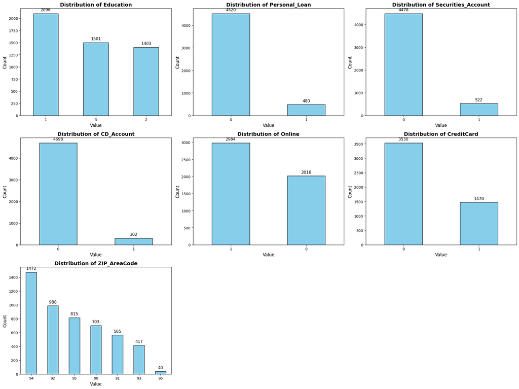

```python
#Create bar plots for Categorical variables
fig, axes = plt.subplots(nrows=3, ncols=3, figsize=(20, 15))
axes = axes.flatten()
for i, col in enumerate(categorical_cols):
    ax = axes[i]

    # Plot the value counts
    ldf[col].value_counts().plot(kind='bar', ax=ax, color='skyblue', edgecolor='black')

    ax.set_title(f'Distribution of {col}', fontsize=14, fontweight='bold')
    ax.set_xlabel('Value', fontsize=12)
    ax.set_ylabel('Count', fontsize=12)
    ax.tick_params(axis='x', rotation=0) # Keep labels upright

    # Value annotations on top of the bars
    for p in ax.patches:
        ax.annotate(str(int(p.get_height())),
                    (p.get_x() + p.get_width() / 2., p.get_height()),
                    ha='center', va='center',
                    xytext=(0, 10), textcoords='offset points', fontsize=11)

for j in range(len(categorical_cols), len(axes)):
    fig.delaxes(axes[j])
plt.tight_layout()
plt.show()
```

Observations:

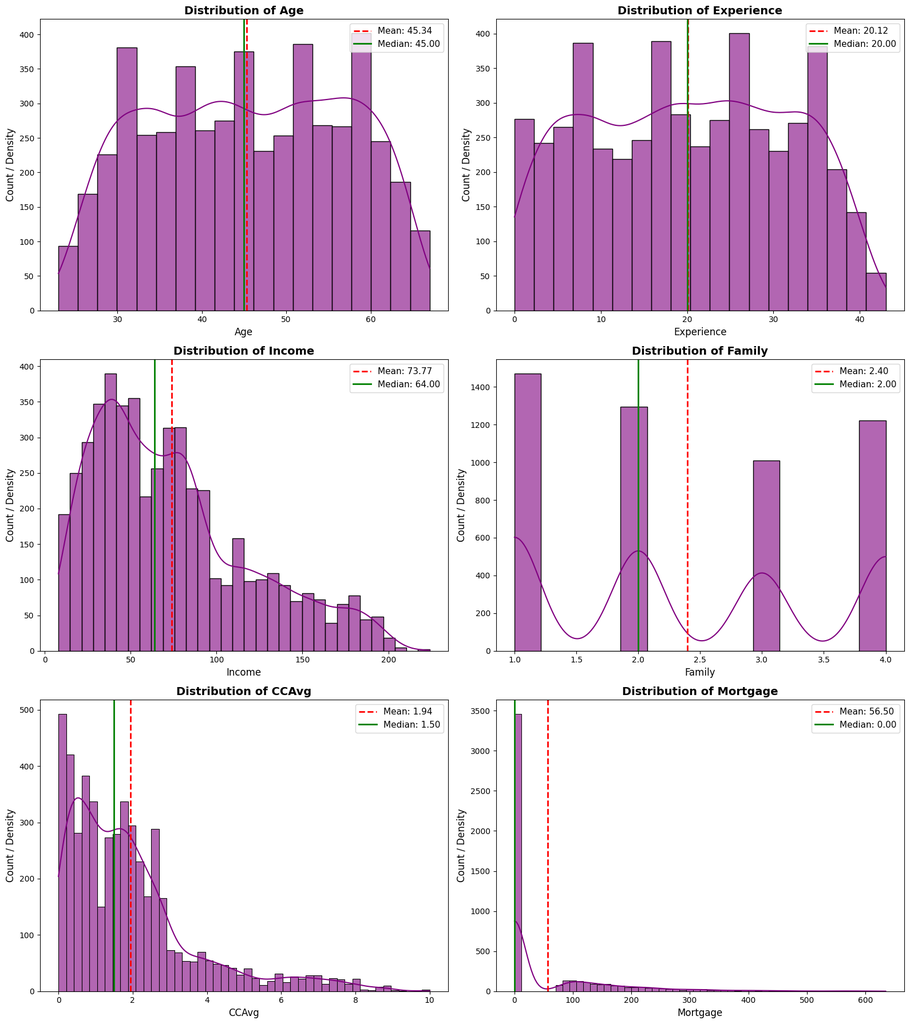

```python
# Select only the continuous/numerical columns
numeric_cols = ldf.select_dtypes(include=['int64', 'float64'])

# Create a 3x2 grid of subplots to fit all 6 numeric variables perfectly
fig, axes = plt.subplots(nrows=3, ncols=2, figsize=(16, 18))
axes = axes.flatten()

for i, col in enumerate(numeric_cols):
    ax = axes[i]

    # Plot Histogram with Kernel Density Estimate
    sns.histplot(data=ldf, x=col, kde=True, ax=ax, color='purple', edgecolor='black', alpha=0.6)

    # Calculate key central tendencies
    mean_val = ldf[col].mean()
    median_val = ldf[col].median()

    # Add vertical lines for Mean and Median to visual check for skewness
    ax.axvline(mean_val, color='red', linestyle='--', linewidth=2, label=f'Mean: {mean_val:.2f}')
    ax.axvline(median_val, color='green', linestyle='-', linewidth=2, label=f'Median: {median_val:.2f}')

    # Formatting adjustments
    ax.set_title(f'Distribution of {col}', fontsize=14, fontweight='bold')
    ax.set_xlabel(col, fontsize=12)
    ax.set_ylabel('Count / Density', fontsize=12)
    ax.legend(fontsize=11, loc='upper right')

# Adjust layout to eliminate overlaps between titles and labels
plt.tight_layout()
plt.show()
```

Observations:

- Age and Experience: Both metrics follow an even, symmetrical distribution across the dataset. The mathematical mean and median values are nearly identical, showing a balanced mix of younger, mid-career, and older individuals with no extreme outliers.
- Income: The distribution is skewed to the right. While the middle-income bracket sits around 64k, a smaller group of high-earning individuals making up to 200k pulls the overall statistical average upward to approximately 73.8k.
- CCAvg (Monthly Credit Card Spend): This variable closely mirrors the right-skewed pattern of income. Most customers spend less than $2k per month on their cards, but a small fraction of high-spending individuals stretches the upper boundary toward 8k to 10k.
- Family: Family size is a discrete metric ranging from 1 to 4 members. Single-person households form the largest individual category, though multi-person households of 2, 3, and 4 members are all consistently represented.
- Mortgage: The distribution displays extreme zero-inflation, meaning the vast majority of customers do not have a home mortgage with this bank. For the minority who do, the values stretch across a wide range, with extreme maximums extending past $600k.

### Bivaritate EDA

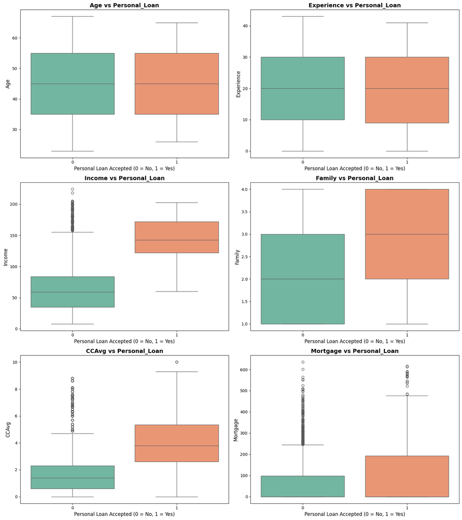

```python
# Set up a 3x2 grid for the 6 numeric features
fig, axes = plt.subplots(nrows=3, ncols=2, figsize=(16, 18))
axes = axes.flatten()

for i, col in enumerate(numeric_cols):
    ax = axes[i]

    # Create boxplot segmented by Personal_Loan acceptance
    sns.boxplot(data=ldf, x='Personal_Loan', y=col, ax=ax, palette='Set2')

    ax.set_title(f'{col} vs Personal_Loan', fontsize=14, fontweight='bold')
    ax.set_xlabel('Personal Loan Accepted (0 = No, 1 = Yes)', fontsize=12)
    ax.set_ylabel(col, fontsize=12)

plt.tight_layout()
plt.show()
```

Observations:

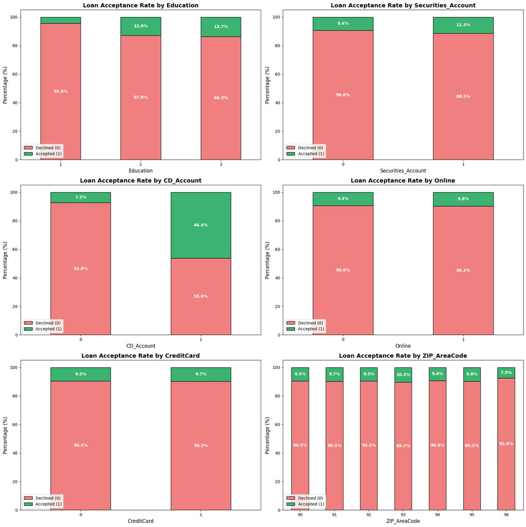

```python
# Select key categorical predictors (excluding the target itself)
#remove target column from categorical_cols and generate bivariate for rest
categorical_cols.remove("Personal_Loan")
# Set up a 3x2 grid for the 6 categorical features
fig, axes = plt.subplots(nrows=3, ncols=2, figsize=(18, 18))
axes = axes.flatten()

for i, col in enumerate(categorical_cols):
    ax = axes[i]

    # Create a contingency table showing percentages
    contingency_pct = pd.crosstab(ldf[col], ldf['Personal_Loan'], normalize='index') * 100

    # Plot 100% stacked bar chart
    contingency_pct.plot(kind='bar', stacked=True, ax=ax, color=['lightcoral', 'mediumseagreen'], edgecolor='black')

    ax.set_title(f'Loan Acceptance Rate by {col}', fontsize=14, fontweight='bold')
    ax.set_xlabel(col, fontsize=12)
    ax.set_ylabel('Percentage (%)', fontsize=12)
    ax.tick_params(axis='x', rotation=0)
    ax.legend(['Declined (0)', 'Accepted (1)'], loc='lower left')

    # Add percentage labels inside the bars
    for p in ax.patches:
        width, height = p.get_width(), p.get_height()
        x, y = p.get_xy()
        if height > 5: # Only label bars with visible segments
            ax.annotate(f'{height:.1f}%', (x + width/2, y + height/2),
                        ha='center', va='center', color='white', fontweight='bold', fontsize=10)

plt.tight_layout()
plt.show()
```

Observations:

- Loan Acceptance Rate by Education: Loan acceptance proportions vary noticeably by education level. Advanced professionals (Level 3) and graduate students (Level 2) exhibit a higher rate of loan acceptance compared to undergraduate individuals (Level 1).
- Loan Acceptance Rate by CD_Account: There is a strong relationship between holding a Certificate of Deposit (CD) account and loan acceptance. A significant percentage of customers with a CD account accepted the personal loan offer, making it a highly relevant predictor.
- Loan Acceptance Rate by Securities_Account: Holding a securities investment account shows a very minimal relationship with loan acceptance. The proportion of individuals accepting the loan remains low regardless of whether a securities account is present.
- Loan Acceptance Rate by Online and CreditCard: Active utilization of online banking or holding a bank-issued credit card does not yield a substantial difference in loan acceptance rates. The split between acceptance and refusal remains relatively constant across these categories.
- Loan Acceptance Rate by ZIP_AreaCode: Loan acceptance rates remain generally uniform across the 7 primary regional two-digit prefixes. Geography, when aggregated at the regional area code level, does not show a dominant influence on customer response.

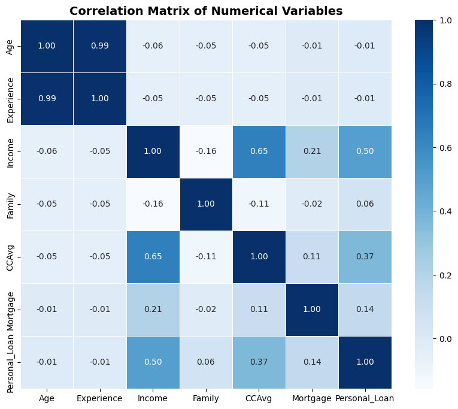

```python
# Temporarily convert target to numeric for correlation mapping
correlation_df = ldf.copy()
correlation_df['Personal_Loan'] = correlation_df['Personal_Loan'].astype(int)

# Filter out only the numeric types for the correlation calculation
numeric_df = correlation_df.select_dtypes(include=['int64', 'float64'])


plt.figure(figsize=(10, 8))
sns.heatmap(numeric_df.corr(), annot=True, fmt='.2f', cmap='Blues', linewidths=0.5)
plt.title('Correlation Matrix of Numerical Variables', fontsize=14, fontweight='bold')
plt.show()
```

Observations:

- Strongest Target Correlation: Income shares the strongest linear correlation with Personal_Loan (0.50), followed by CCAvg (0.37). This reinforces the observation that financial capacity and spending trends are the primary numerical indicators of loan acceptance.
- Features: Age and Experience show an almost perfect linear correlation (-0.01 relative to the target, but nearly 1.00 with each other), meaning not much impact or correlation.
- Income and Spending Connection: A strong positive correlation exists between Income and CCAvg (0.65), indicating that higher earners predictably spend more on their credit cards monthly.

## Data Preprocessing

- Missing value treatment
- Feature engineering (if needed)
- Outlier detection and treatment (if needed)
- Preparing data for modeling
- Any other preprocessing steps (if needed)

```python
# check for any missing values
ldf.isnull().sum()
```

|  | 0 |
| --- | --- |
| Age | 0 |
| Experience | 0 |
| Income | 0 |
| Family | 0 |
| CCAvg | 0 |
| Education | 0 |
| Mortgage | 0 |
| Personal_Loan | 0 |
| Securities_Account | 0 |
| CD_Account | 0 |
| Online | 0 |
| CreditCard | 0 |
| ZIP_AreaCode | 0 |

**dtype:** int64

Observation on Missing Values: The dataset contains zero missing values across all columns, meaning no imputation steps (fillna) are necessary.

```python
# Calculate IQR boundaries
Q1 = numeric_cols.quantile(0.25)  # 25th percentile
Q3 = numeric_cols.quantile(0.75)  # 75th percentile
IQR = Q3 - Q1                     # Interquartile Range

# Define upper and lower limit thresholds
lower_bound = Q1 - 1.5 * IQR
upper_bound = Q3 + 1.5 * IQR

# Calculate and display the percentage of outliers per feature
print("--- Percentage of Outliers Per Column ---")
outlier_percentage = ((numeric_cols < lower_bound) | (numeric_cols > upper_bound)).sum() / len(ldf) * 100
print(outlier_percentage.round(2).astype(str) + '%')
```

```
--- Percentage of Outliers Per Column ---
Age            0.0%
Experience     0.0%
Income        1.92%
Family         0.0%
CCAvg         6.48%
Mortgage      5.82%
dtype: object
```

Outlier Observations:

- All detected outliers across Income, CCAvg, and Mortgage looks to be real, valid financial profiles of high-value banking clients rather than data entry errors.
- As these high-value indicators are highly relevant to identifying potential targets for a Personal_Loan, these records should be preserved in the dataset rather than removed or capped before training the machine learning models.

### Model Prep

```python
X = ldf.drop('Personal_Loan', axis=1)
y = ldf['Personal_Loan']

dummy_cols = ['Education', 'ZIP_AreaCode']
X = pd.get_dummies(X, columns=dummy_cols, drop_first=True)
X = X.astype(float)
```

```python
X.info()
```

```
<class 'pandas.core.frame.DataFrame'>
RangeIndex: 5000 entries, 0 to 4999
Data columns (total 18 columns):
 #   Column              Non-Null Count  Dtype
---  ------              --------------  -----
 0   Age                 5000 non-null   float64
 1   Experience          5000 non-null   float64
 2   Income              5000 non-null   float64
 3   Family              5000 non-null   float64
 4   CCAvg               5000 non-null   float64
 5   Mortgage            5000 non-null   float64
 6   Securities_Account  5000 non-null   float64
 7   CD_Account          5000 non-null   float64
 8   Online              5000 non-null   float64
 9   CreditCard          5000 non-null   float64
 10  Education_2         5000 non-null   float64
 11  Education_3         5000 non-null   float64
 12  ZIP_AreaCode_91     5000 non-null   float64
 13  ZIP_AreaCode_92     5000 non-null   float64
 14  ZIP_AreaCode_93     5000 non-null   float64
 15  ZIP_AreaCode_94     5000 non-null   float64
 16  ZIP_AreaCode_95     5000 non-null   float64
 17  ZIP_AreaCode_96     5000 non-null   float64
dtypes: float64(18)
memory usage: 703.3 KB
```

```python
# Split the train and test data
X_train, X_test, y_train, y_test = train_test_split(X, y, test_size=0.2, random_state=42, stratify=y)
print("Train data shape:", X_train.shape)
print("Test data shape:", X_test.shape)
print(y_train.value_counts(normalize=True))
print(y_test.value_counts(normalize=True))
```

```
Train data shape: (4000, 18)
Test data shape: (1000, 18)
Personal_Loan
0    0.904
1    0.096
Name: proportion, dtype: float64
Personal_Loan
0    0.904
1    0.096
Name: proportion, dtype: float64
```

## Model Building

### Model Evaluation Criterion

Main criteria for decision trees are of 1. Recall, 2. Preceision 3. Accuracy 4. F1 score. As we are targeting the potential customer to do personal loan, it is fine to get False Postives but cannot afford False Negatives, as it is way more costly to loose bussiness than checking with extra customers. So, I think Recall would be a good criteria but we need to compare against all the other metrics like F1, precision etc

```python
# define a function to compute different metrics like [1. Recall, 2. Preceision 3. Accuracy 4. F1 score ] to check performance of a classification model
# take argumnets as [model , input data , target data ] and
# return [eval of each one in data frame]
def model_eval(model, X, y):
    y_pred = model.predict(X)
    recall = recall_score(y, y_pred)
    precision = precision_score(y, y_pred)
    accuracy = accuracy_score(y, y_pred)
    f1 = f1_score(y, y_pred)

    model_eval_df = pd.DataFrame({'Model': [model], 'Recall': [recall], 'Precision': [precision], 'Accuracy': [accuracy], 'F1': [f1]})
    return  model_eval_df
```

```python
# define a function to compute confusion Matrix
# take argumnets as [model , input data , target data ] and
# return [eval of each one in data frame]
def plot_confusion_matrix(model, X, y):
    y_pred = model.predict(X)
    cm = confusion_matrix(y, y_pred)
    sns.heatmap(cm, annot=True, fmt='d', cmap='Blues')
    plt.title('Confusion Matrix')
    plt.xlabel('Predicted Labels')
    plt.ylabel('True Labels')
    plt.show()
```

### Model Building

```python
#build a decision tree
from sklearn.tree import DecisionTreeClassifier
dt_model = DecisionTreeClassifier(random_state=42)
dt_model.fit(X_train, y_train)
```

```
DecisionTreeClassifier(random_state=42)
```

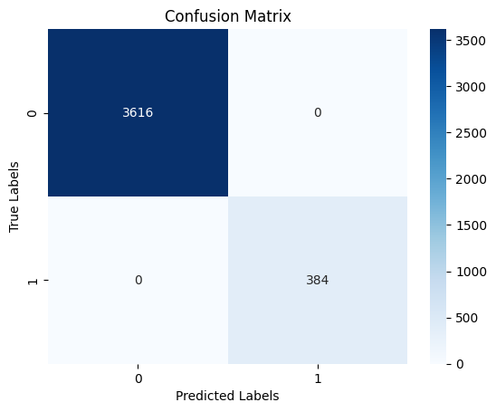

```python
#check confusion matrix for the train data
plot_confusion_matrix(dt_model, X_train, y_train)
```

```python
#check model perf eval on train data
model_eval(dt_model, X_train, y_train)
```

|  | Model | Recall | Precision | Accuracy | F1 |
| --- | --- | --- | --- | --- | --- |
| 0 | DecisionTreeClassifier(random_state=42) | 1.0 | 1.0 | 1.0 | 1.0 |

Observation on Train data:

- Looks like this is overfitted as all the tree is setup for full 100% results
- possibly need to do prepruning the tree to avoid overfitting

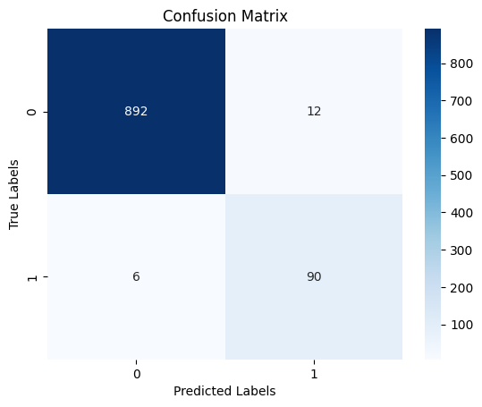

```python
# check Confusion Matrix on Test data
plot_confusion_matrix(dt_model, X_test, y_test)
```

```python
# check Model perf eval on test data
model_eval(dt_model, X_test, y_test)
```

|  | Model | Recall | Precision | Accuracy | F1 |
| --- | --- | --- | --- | --- | --- |
| 0 | DecisionTreeClassifier(random_state=42) | 0.9375 | 0.882353 | 0.982 | 0.909091 |

Observation on Test data and overall model

- Looks like Test data also looks good as the predictions are over 90%
- but the actual Train data model perfromed 100% and Test data has 93% only for recall and for precision and F1 scores have even higher gaps !!
- this higher diff shows this model is NOT gives us generalized performance and it is overfitted on train data
- Solution: Need to do some Pre Pruning to avoid this overfitting

```python
#visualize the decision tree
import graphviz
from sklearn.tree import export_graphviz
dot_data = export_graphviz(dt_model, out_file=None, feature_names=X.columns, class_names=['0', '1'], filled=True, rounded=True, special_characters=True)
graph = graphviz.Source(dot_data)
graph.render("decision_tree", format="png")
graph
```

[figure not shown]

```python
#visualize and export to the text and print in hireachical order
from sklearn.tree import export_text
tree_rules = export_text(dt_model, feature_names=list(X.columns))
print(tree_rules)
```

```
|--- Income <= 98.50
|   |--- CCAvg <= 2.95
|   |   |--- class: 0
|   |--- CCAvg >  2.95
|   |   |--- CD_Account <= 0.50
|   |   |   |--- Income <= 92.50
|   |   |   |   |--- Age <= 27.00
|   |   |   |   |   |--- class: 1
|   |   |   |   |--- Age >  27.00
|   |   |   |   |   |--- CCAvg <= 3.65
|   |   |   |   |   |   |--- Mortgage <= 216.50
|   |   |   |   |   |   |   |--- Income <= 82.50
|   |   |   |   |   |   |   |   |--- Age <= 36.50
|   |   |   |   |   |   |   |   |   |--- Education_2 <= 0.50
|   |   |   |   |   |   |   |   |   |   |--- class: 0
|   |   |   |   |   |   |   |   |   |--- Education_2 >  0.50
|   |   |   |   |   |   |   |   |   |   |--- CCAvg <= 3.50
|   |   |   |   |   |   |   |   |   |   |   |--- class: 1
|   |   |   |   |   |   |   |   |   |   |--- CCAvg >  3.50
|   |   |   |   |   |   |   |   |   |   |   |--- class: 0
|   |   |   |   |   |   |   |   |--- Age >  36.50
|   |   |   |   |   |   |   |   |   |--- ZIP_AreaCode_91 <= 0.50
|   |   |   |   |   |   |   |   |   |   |--- class: 0
|   |   |   |   |   |   |   |   |   |--- ZIP_AreaCode_91 >  0.50
|   |   |   |   |   |   |   |   |   |   |--- Age <= 46.00
|   |   |   |   |   |   |   |   |   |   |   |--- truncated branch of depth 2
|   |   |   |   |   |   |   |   |   |   |--- Age >  46.00
|   |   |   |   |   |   |   |   |   |   |   |--- class: 0
|   |   |   |   |   |   |   |--- Income >  82.50
|   |   |   |   |   |   |   |   |--- CCAvg <= 3.05
|   |   |   |   |   |   |   |   |   |--- class: 0
|   |   |   |   |   |   |   |   |--- CCAvg >  3.05
|   |   |   |   |   |   |   |   |   |--- Education_3 <= 0.50
|   |   |   |   |   |   |   |   |   |   |--- Family <= 1.50
|   |   |   |   |   |   |   |   |   |   |   |--- truncated branch of depth 2
|   |   |   |   |   |   |   |   |   |   |--- Family >  1.50
|   |   |   |   |   |   |   |   |   |   |   |--- class: 0
|   |   |   |   |   |   |   |   |   |--- Education_3 >  0.50
|   |   |   |   |   |   |   |   |   |   |--- Mortgage <= 94.00
|   |   |   |   |   |   |   |   |   |   |   |--- class: 1
```

[output cut: 129 more lines]

```
|   |   |   |   |--- Age <= 59.50
|   |   |   |   |   |--- Online <= 0.50
|   |   |   |   |   |   |--- class: 1
|   |   |   |   |   |--- Online >  0.50
|   |   |   |   |   |   |--- Education_3 <= 0.50
|   |   |   |   |   |   |   |--- Experience <= 34.00
|   |   |   |   |   |   |   |   |--- class: 0
|   |   |   |   |   |   |   |--- Experience >  34.00
|   |   |   |   |   |   |   |   |--- class: 1
|   |   |   |   |   |   |--- Education_3 >  0.50
|   |   |   |   |   |   |   |--- class: 1
|   |   |   |   |--- Age >  59.50
|   |   |   |   |   |--- class: 0
|   |   |--- Income >  114.50
|   |   |   |--- class: 1
```

```python
#print all metric of the tree like depth, number of leaf nodes, splits
print("Tree Depth:", dt_model.get_depth())
print("Number of Leaf Nodes:", dt_model.get_n_leaves())
print("Number of Splits:", dt_model.tree_.node_count)
```

```
Tree Depth: 12
Number of Leaf Nodes: 64
Number of Splits: 127
```

Observation:

- Classificaiton decision Tree is TOO big and deep
- prepurining is to be done to avoid these many branches

## Model Performance Improvement

### Pre-Pruning

```python
#  preprune the tree by iterating over all combinations of "max_depth", max_leaf_nodes and "min_samples_split" and find the best fitting model by comapring the model_eval scores

# define combinations of vairables
max_depth_values = [3, 4, 5, 6, 7, 8]
max_leaf_nodes_values = [50, 75, 150, 250]
min_samples_split_values = [5, 10, 20, 50, 100]

# Initialize trackers for the best model setup
best_recall = float('inf')
dt_model_pruned = None
best_params = {}
best_test_recall = 0.0

print("Iterating over hyperparameter combinations...")

# Triple nested loop to iterate over all parameter combinations
for depth in max_depth_values:
    for leaf_nodes in max_leaf_nodes_values:
        for split in min_samples_split_values:

            # Initialize the tree with the current parameter set
            current_model = DecisionTreeClassifier(
                max_depth=depth,
                max_leaf_nodes=leaf_nodes,
                min_samples_split=split,
                random_state=42
            )
            current_model.fit(X_train, y_train)

            # Evaluate current model using train data
            eval_df_train = model_eval(current_model, X_train, y_train)
            current_recall_train = eval_df_train['Recall'].values[0]

            # Evaluate current model using test data
            eval_df_test = model_eval(current_model, X_test, y_test)
            current_recall_test = eval_df_test['Recall'].values[0]
            #get the diff of test and train abs diff
            current_recall = abs(current_recall_train-current_recall_test)

            # Save the model if it yields a less Recall diff b/w test and train
            if (current_recall < best_recall) & (current_recall_test > best_test_recall):
                best_recall = current_recall
                dt_model_pruned = current_model
                best_test_recall = current_recall_test
                best_params = {
                    'max_depth': depth,
                    'max_leaf_nodes': leaf_nodes,
                    'min_samples_split': split
                }

# Output the results of the best fitting model configuration
print("\n--- Pre-Pruning Complete ---")
print(f"Best Parameters Found: {best_params}")
print(f" Training Test Recall Score: {best_test_recall:.4f}")
```

```
Iterating over hyperparameter combinations...

--- Pre-Pruning Complete ---
Best Parameters Found: {'max_depth': 6, 'max_leaf_nodes': 50, 'min_samples_split': 5}
 Training Test Recall Score: 0.9583
```

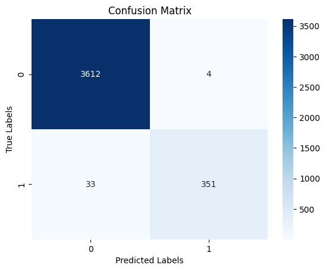

|  | Model | Recall | Precision | Accuracy | F1 |
| --- | --- | --- | --- | --- | --- |
| 0 | DecisionTreeClassifier(max_depth=6, max_leaf_n... | 0.914062 | 0.988732 | 0.99075 | 0.949932 |

```python
#take the best model and fit the train data and check performance
#check confusion matrix and model performance on train data
plot_confusion_matrix(dt_model_pruned, X_train, y_train)
model_eval(dt_model_pruned, X_train, y_train)
```

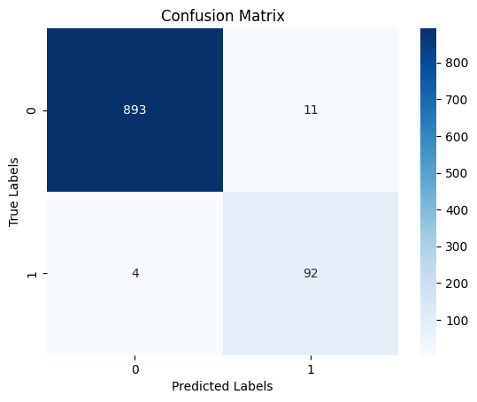

|  | Model | Recall | Precision | Accuracy | F1 |
| --- | --- | --- | --- | --- | --- |
| 0 | DecisionTreeClassifier(max_depth=6, max_leaf_n... | 0.958333 | 0.893204 | 0.985 | 0.924623 |

```python
# check performance of this best model on test data
plot_confusion_matrix(dt_model_pruned, X_test, y_test)
model_eval(dt_model_pruned, X_test, y_test)
```

```python
# visulize this pruned tree
import graphviz
from sklearn.tree import export_graphviz
dot_data = export_graphviz(dt_model_pruned, out_file=None, feature_names=X.columns, class_names=['0', '1'], filled=True, rounded=True, special_characters=True)
graph = graphviz.Source(dot_data)
graph.render("decision_tree_pruned", format="png")
graph
```

[figure not shown]

```python
#print all metric of the tree like depth, number of leaf nodes, splits
print("Tree Depth:",  dt_model_pruned.get_depth())
print("Number of Leaf Nodes:", dt_model_pruned.get_n_leaves())
print("Number of Splits:", dt_model_pruned.tree_.node_count)
```

```
Tree Depth: 6
Number of Leaf Nodes: 27
Number of Splits: 53
```

Observations:

### Post Pruning tree model

```python
# Initialize a DecisionTreeClassifier for post-pruning. We start with a fully grown tree.
dt_model_post_pruned = DecisionTreeClassifier(random_state=42)
dt_model_post_pruned.fit(X_train, y_train)

# Calculate the cost-complexity pruning path. This computes the effective alphas
# and the corresponding total impurities of the leaves for different pruning levels.
path = dt_model_post_pruned.cost_complexity_pruning_path(X_train, y_train)

# Extract the effective alpha values and their corresponding total impurities.
# We take the absolute value of ccp_alphas to ensure they are positive.
ccp_alphas = abs(path.ccp_alphas)
impurities = path.impurities

# Display the ccp_alphas and impurities in a DataFrame for review.
pd.DataFrame(path)
```

|  | ccp_alphas | impurities |
| --- | --- | --- |
| 0 | 0.000000 | 0.000000 |
| 1 | 0.000162 | 0.000487 |
| 2 | 0.000164 | 0.000980 |
| 3 | 0.000247 | 0.001473 |
| 4 | 0.000306 | 0.002392 |
| 5 | 0.000333 | 0.002726 |
| 6 | 0.000333 | 0.003059 |
| 7 | 0.000333 | 0.003392 |
| 8 | 0.000351 | 0.004796 |
| 9 | 0.000373 | 0.006288 |
| 10 | 0.000375 | 0.006663 |
| 11 | 0.000400 | 0.007063 |
| 12 | 0.000417 | 0.007480 |
| 13 | 0.000419 | 0.009996 |
| 14 | 0.000425 | 0.011271 |
| 15 | 0.000428 | 0.012127 |
| 16 | 0.000444 | 0.012571 |
| 17 | 0.000450 | 0.013021 |
| 18 | 0.000450 | 0.013921 |
| 19 | 0.000493 | 0.014906 |
| 20 | 0.000675 | 0.015581 |
| 21 | 0.000779 | 0.016360 |
| 22 | 0.000782 | 0.017923 |
| 23 | 0.000823 | 0.018746 |
| 24 | 0.000833 | 0.020412 |
| 25 | 0.000854 | 0.021265 |
| 26 | 0.001159 | 0.022424 |
| 27 | 0.001667 | 0.024091 |
| 28 | 0.002100 | 0.026191 |
| 29 | 0.002281 | 0.028473 |
| 30 | 0.002424 | 0.030897 |
| 31 | 0.002667 | 0.033564 |
| 32 | 0.004094 | 0.037658 |
| 33 | 0.006141 | 0.043799 |
| 34 | 0.013136 | 0.056935 |
| 35 | 0.020935 | 0.098805 |
| 36 | 0.029783 | 0.128587 |
| 37 | 0.044981 | 0.173568 |

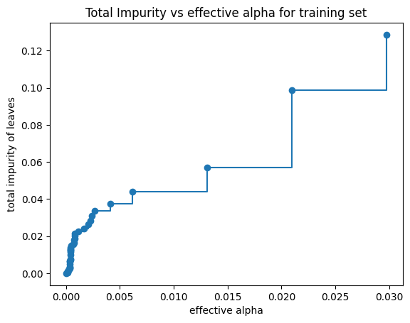

```python
# Plot the total impurity of leaves against the effective alpha values.
# to check if increasing alpha reduces the tree's complexity and changes the impurity.
fig, ax = plt.subplots()
ax.plot(ccp_alphas[:-1], impurities[:-1], marker='o', drawstyle="steps-post")
ax.set_xlabel("effective alpha")
ax.set_ylabel("total impurity of leaves")
ax.set_title("Total Impurity vs effective alpha for training set")
plt.show()
```

```python
# Next, we train a decision tree using the effective alphas.
# The last value in ccp_alphas is the alpha value that prunes the whole tree, leaving the corresponding tree with one node

# Create a list to store DecisionTreeClassifier instances, each pruned with a different ccp_alpha.
clfs = []
# Iterate through each effective alpha value.
for ccp_alpha in ccp_alphas:
    # Initialize a DecisionTreeClassifier with the current ccp_alpha.
    clf = DecisionTreeClassifier(random_state=42, ccp_alpha=ccp_alpha)
    # Fit the model to the training data.
    clf.fit(X_train, y_train)
    # Add the trained model to the list.
    clfs.append(clf)

print("Number of trees in the ccp_alpha path: ", len(clfs))
```

```
Number of trees in the ccp_alpha path:  38
```

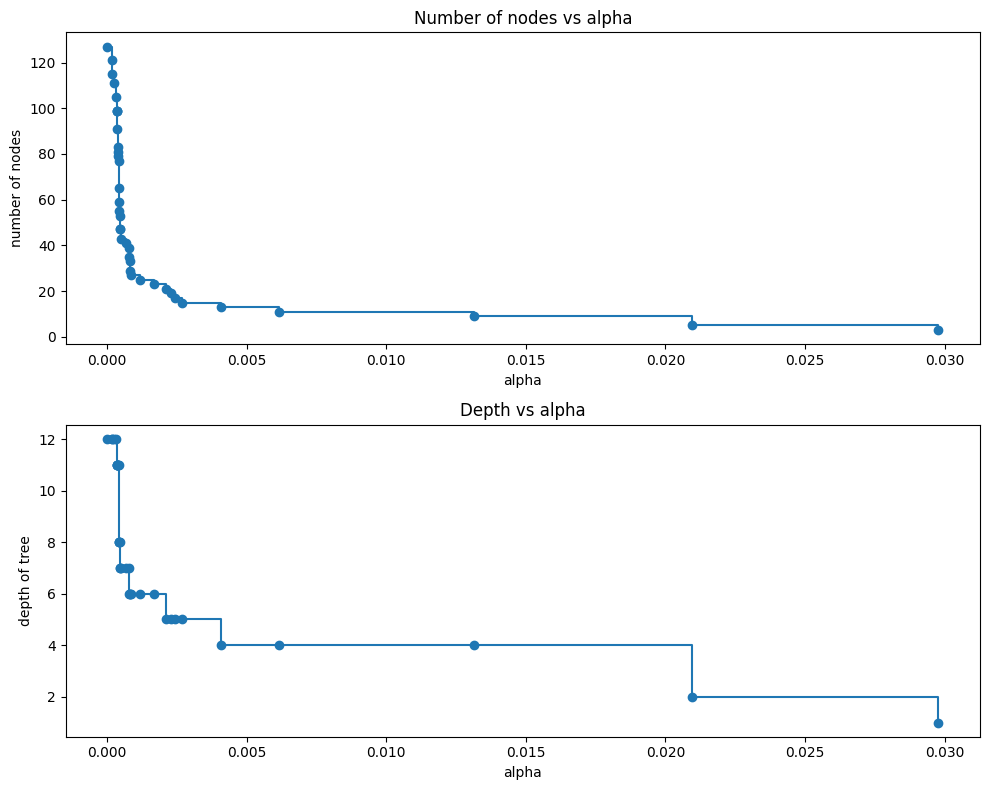

```python
# Exclude the last tree, which is typically just the root node (fully pruned tree) and not useful for analysis.
clfs = clfs[:-1]
ccp_alphas = ccp_alphas[:-1]

# Get the number of nodes and depth for each pruned tree in the 'clfs' list.
node_counts = [clf.tree_.node_count for clf in clfs]
depth = [clf.tree_.max_depth for clf in clfs]

# Create a figure with two subplots to visualize the impact of alpha on tree complexity.
fig, ax = plt.subplots(2, 1, figsize=(10, 8))

# Plot: Number of nodes vs. alpha.
ax[0].plot(ccp_alphas, node_counts, marker='o', drawstyle="steps-post")
ax[0].set_xlabel("alpha")
ax[0].set_ylabel("number of nodes")
ax[0].set_title("Number of nodes vs alpha")

# Plot: Depth of tree vs. alpha.
ax[1].plot(ccp_alphas, depth, marker='o', drawstyle="steps-post")
ax[1].set_xlabel("alpha")
ax[1].set_ylabel("depth of tree")
ax[1].set_title("Depth vs alpha")

# Adjust layout to prevent overlapping titles/labels.
fig.tight_layout()
plt.show()
```

Observations: The graphs show that an effective alpha value chosen from the stable middle zone (between 0.002 and 0.008) will succeed in reducing your tree's depth from a bloated 12 levels down to a highly readable 4 to 5 levels, perfectly balancing simplicity with predictive power

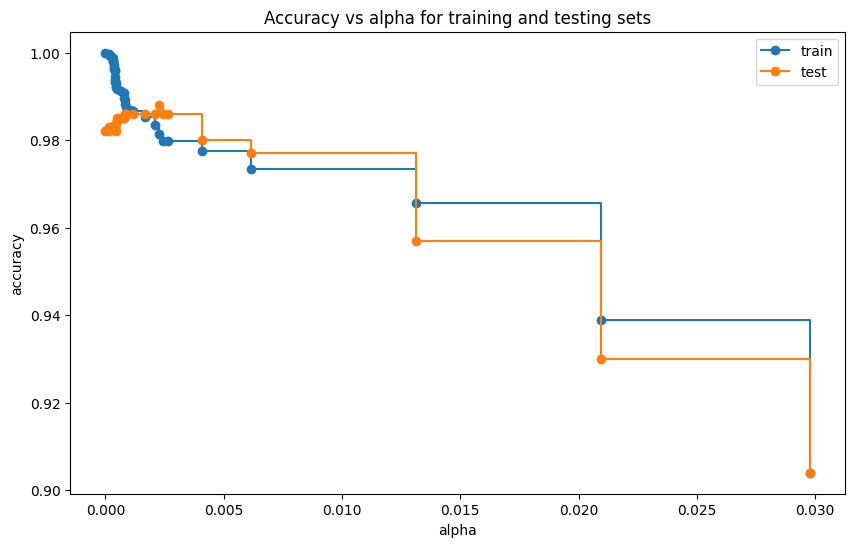

```python
# Calculate the accuracy scores for each pruned tree on both the training and testing sets.
train_scores = [clf.score(X_train, y_train) for clf in clfs]
test_scores = [clf.score(X_test, y_test) for clf in clfs]

# Plot the accuracy scores against the effective alpha values.
# This helps identify the alpha value that provides the best balance between bias and variance (optimal generalization).
fig, ax = plt.subplots(figsize=(10, 6))
ax.set_xlabel("alpha")
ax.set_ylabel("accuracy")
ax.set_title("Accuracy vs alpha for training and testing sets")

# Plot training accuracy.
ax.plot(ccp_alphas, train_scores, marker='o', label="train", drawstyle="steps-post")
# Plot testing accuracy.
ax.plot(ccp_alphas, test_scores, marker='o', label="test", drawstyle="steps-post")

ax.legend()
plt.show()
```

```python
# Find the index of the ccp_alpha that yields the highest accuracy on the test set.
alpha_idx_best = np.argmax(test_scores)
# Retrieve the optimal ccp_alpha value.
best_ccp_alpha = ccp_alphas[alpha_idx_best]

print(f"Optimal ccp_alpha: {best_ccp_alpha:.6f}")
```

```
Optimal ccp_alpha: 0.002281
```

```
Post-pruned Decision Tree (final) - Train Data:
```

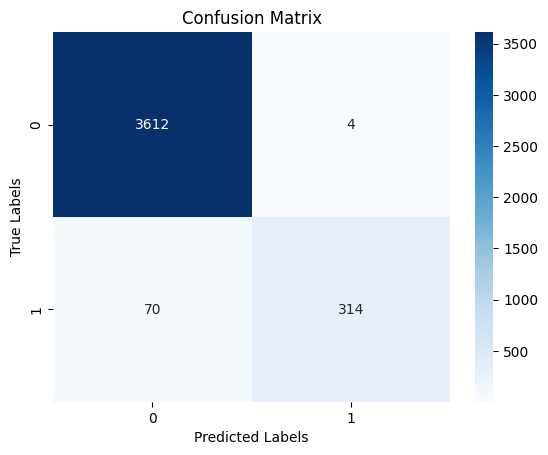

|  | Model | Recall | Precision | Accuracy | F1 |
| --- | --- | --- | --- | --- | --- |
| 0 | DecisionTreeClassifier(ccp_alpha=np.float64(0.... | 0.817708 | 0.987421 | 0.9815 | 0.894587 |

```python
# Train the final post-pruned Decision Tree model using the optimal ccp_alpha found.
dt_model_post_pruned_final = DecisionTreeClassifier(random_state=42, ccp_alpha=best_ccp_alpha)
dt_model_post_pruned_final.fit(X_train, y_train)

# Evaluate the final post-pruned model on the training data.
print("Post-pruned Decision Tree (final) - Train Data:")
plot_confusion_matrix(dt_model_post_pruned_final, X_train, y_train)
model_eval(dt_model_post_pruned_final, X_train, y_train)
```

```
Post-pruned Decision Tree (final) - Test Data:
```

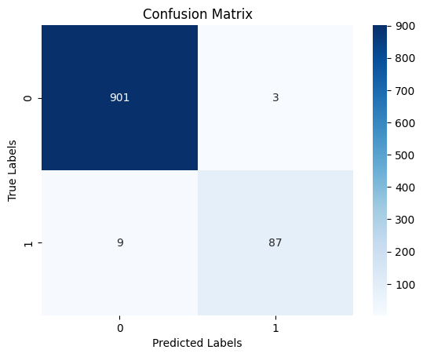

|  | Model | Recall | Precision | Accuracy | F1 |
| --- | --- | --- | --- | --- | --- |
| 0 | DecisionTreeClassifier(ccp_alpha=np.float64(0.... | 0.90625 | 0.966667 | 0.988 | 0.935484 |

```python
# Evaluate the final post-pruned model on the test data.
print("\nPost-pruned Decision Tree (final) - Test Data:")
plot_confusion_matrix(dt_model_post_pruned_final, X_test, y_test)
model_eval(dt_model_post_pruned_final, X_test, y_test)
```

```python
# Export the final post-pruned decision tree to a DOT format string.
dot_data_post = export_graphviz(dt_model_post_pruned_final, out_file=None, feature_names=X.columns, class_names=['0', '1'], filled=True, rounded=True, special_characters=True)

# Create a graph from the DOT data.
graph_post = graphviz.Source(dot_data_post)

# Render the graph to a PNG file and display it.
graph_post.render("decision_tree_post_pruned_final", format="png")
graph_post
```

[figure not shown]

```python
#visualize and export to the text and print in hireachical order
tree_rules_post = export_text(dt_model_post_pruned_final, feature_names=list(X.columns))
print(tree_rules_post)
```

```
|--- Income <= 98.50
|   |--- CCAvg <= 2.95
|   |   |--- class: 0
|   |--- CCAvg >  2.95
|   |   |--- CD_Account <= 0.50
|   |   |   |--- class: 0
|   |   |--- CD_Account >  0.50
|   |   |   |--- class: 1
|--- Income >  98.50
|   |--- Family <= 2.50
|   |   |--- Education_3 <= 0.50
|   |   |   |--- Education_2 <= 0.50
|   |   |   |   |--- class: 0
|   |   |   |--- Education_2 >  0.50
|   |   |   |   |--- Income <= 116.50
|   |   |   |   |   |--- class: 0
|   |   |   |   |--- Income >  116.50
|   |   |   |   |   |--- class: 1
|   |   |--- Education_3 >  0.50
|   |   |   |--- Income <= 114.50
|   |   |   |   |--- class: 0
|   |   |   |--- Income >  114.50
|   |   |   |   |--- class: 1
|   |--- Family >  2.50
|   |   |--- Income <= 114.50
|   |   |   |--- class: 0
|   |   |--- Income >  114.50
|   |   |   |--- class: 1
```

```python
# Print key metrics of the final post-pruned tree to understand its complexity.
print("Tree Depth:", dt_model_post_pruned_final.get_depth())
print("Number of Leaf Nodes:", dt_model_post_pruned_final.get_n_leaves())
print("Number of Splits:", dt_model_post_pruned_final.tree_.node_count)
```

```
Tree Depth: 5
Number of Leaf Nodes: 10
Number of Splits: 19
```

Observations: Post Pruned Final Model have depth of 5 and only 19 splits but pre-pruned have 6 and 53 splits. Next step is to compare all kinds of scrores for all the best models and evaluate.

## Model Performance Comparison and Final Model Selection

```python
models = [
    ('Unpruned', dt_model),
    ('Pre-pruned', dt_model_pruned),
    ('Post-pruned', dt_model_post_pruned_final)
]

model_names = []
recall_scores = []
precision_scores = []
accuracy_scores = []
f1_scores = []
depths = []

for name, model in models:
    # Evaluate on Train Data
    train_eval = model_eval(model, X_train, y_train)
    model_names.append(f'{name} (Train)')
    recall_scores.append(train_eval['Recall'].values[0])
    precision_scores.append(train_eval['Precision'].values[0])
    accuracy_scores.append(train_eval['Accuracy'].values[0])
    f1_scores.append(train_eval['F1'].values[0])
    depths.append(model.get_depth())

    # Evaluate on Test Data
    test_eval = model_eval(model, X_test, y_test)
    model_names.append(f'{name} (Test)')
    recall_scores.append(test_eval['Recall'].values[0])
    precision_scores.append(test_eval['Precision'].values[0])
    accuracy_scores.append(test_eval['Accuracy'].values[0])
    f1_scores.append(test_eval['F1'].values[0])
    depths.append(model.get_depth())

# Create a summary DataFrame for easy comparison
comparison_df = pd.DataFrame({
    'Model': model_names,
    'Recall': recall_scores,
    'Precision': precision_scores,
    'Accuracy': accuracy_scores,
    'F1': f1_scores,
    'Depth': depths
})

comparison_df.round(4)
```

|  | Model | Recall | Precision | Accuracy | F1 | Depth |
| --- | --- | --- | --- | --- | --- | --- |
| 0 | Unpruned (Train) | 1.0000 | 1.0000 | 1.0000 | 1.0000 | 12 |
| 1 | Unpruned (Test) | 0.9375 | 0.8824 | 0.9820 | 0.9091 | 12 |
| 2 | Pre-pruned (Train) | 0.9141 | 0.9887 | 0.9908 | 0.9499 | 6 |
| 3 | Pre-pruned (Test) | 0.9583 | 0.8932 | 0.9850 | 0.9246 | 6 |
| 4 | Post-pruned (Train) | 0.8177 | 0.9874 | 0.9815 | 0.8946 | 5 |
| 5 | Post-pruned (Test) | 0.9062 | 0.9667 | 0.9880 | 0.9355 | 5 |

Observations from Model Performance Evaluation:

- Unpruned Model: Exhibits perfect scores on the training data (Recall 1.0, Precision 1.0, Accuracy 1.0, F1 1.0) but shows a drop in test performance (Test Recall 0.9375, Test Precision 0.8824, Test F1 0.9091). This confirms significant overfitting, as indicated by its high depth of 12.
- Pre-pruned Model: Demonstrates a better balance between training and test performance. It achieves a Test Recall of 0.9583, which is the highest among all models. Its Test F1 score is 0.9246, and Test Accuracy is 0.985. The depth is significantly reduced to 6, indicating improved generalization.
- Post-pruned Model: Shows good overall test performance with the highest Test Accuracy (0.988) and Test F1 score (0.9355). Its depth is the lowest at 5, suggesting a very compact model. However, its Test Recall is 0.9062, which is lower than the pre-pruned model.

Conclusion on Model Selection:

- Considering the objective of maximizing the identification of potential loan customers (i.e., minimizing false negatives), Recall is the most critical metric. Therefore, the Pre-pruned model is the preferred choice, as it yields the highest Test Recall (0.9583) while still providing a well-generalized model with reduced complexity compared to the unpruned version. Although the post-pruned model has slightly higher F1 and Accuracy but has lower Recall score. So, considering current bussiness need, pre-pruning is good.

## Actionable Insights and Business Recommendations

- What recommedations would you suggest to the bank?
1. Target High-Income, High-Spending Customers:
- Recommendation: Prioritize marketing efforts towards existing liability customers with higher annual incomes and above-average monthly credit card spending (CCAvg). The model clearly shows these are the strongest correlation of personal loan acceptance.
- Action: Develop targeted campaigns for these kind of customers
2. Leverage CD Account Holders:
- Recommendation: Customers holding a Certificate of Deposit (CD) account show a significantly higher propensity to accept personal loans. This is a strong demographic segment to target.
- Action: Create specialized offers and messaging for CD account holders by highlighting personal loans.
3. Focus on Higher Education Segments:
- Recommendation: Individuals with Graduate or Advanced/Professional education levels are more likely to accept personal loans. These section of individuals to be more financially literate and may be seeking loans for investment or strategic purposes and online engagement is high.
- Action: Target marketing content towards the financial goals and understanding of these educated segments, emphasizing benefits like lower interest rates for qualified borrower, etc.
4. Account for Family Size
- Recommendation: Multi-person households (family sizes of 3 and 4) show a minor positive correlation and trend upward in loan acceptance compared to single individuals, possibly higher needs.
- Action: Start family-centric marketing campaigns like financing options or home improvement loans, tailored to the structural needs of larger households.
5. Personalize Offers and Communication:
- Recommendation: Utilize this decision tree rules to personalize loan offers and communication. The model gives information on understanding if a cusotmer is good candidate and why a customer might be a good candidate for personal loan.
- Action: For example, a customer with high income and a CD account could be n offered financial flexibility repayment, while a graduate with high CCAvg might be offered with large purchases monthly payment loan plan, etc.